# RPC Users Guide

## Overview

Remote Procedure Call (RPC) is a technology which allows a program to invoke a procedure on a remote entity. The details of the remote interaction are abstracted from the call site, allowing to code to look natural, as if the procedure were executing locally.

An IDL (Interface Description Language) file is used to describe a software component’s interface. This file describes the data types and functions. The function descriptions are grouped into interfaces.

An IDL compiler is used to generate run-time code which performs marshalling of the function arguments. Code is generated for both sides of the connection: the local side (client) and the remote side (server). This code must be compiled and linked into their respective executables.

The SysConfig tool is used for generating setup code and creating the transport objects needed by RPC.

## Interface Description Language file

The IDL file describes a software component’s interface. Each IDL file may describe one or more interfaces. A program may use one or more IDL files. Here is an example of a simple IDL file. Note the file extension: `.erpc`.

```
basic.erpc
--------------
program basic

interface basic
{
    Basic_add(int32 x, int32 y) -> int32
}
```

This IDL file will generate the following source files:

```
basic.h
basic_client.cpp    - contains stub functions (client)
basic_server.h
basic_server.cpp    - contains skel functions (server)
```

These source files contain the run-time marshalling code needed to implement the stub and skel functions. However, the actual interface implementation is not generated. This must be provided. For example, the following file provides an implementation of the interface above:

```
basic.c
-----------
int32_t Basic_add(int32_t x, int32_t y)
{
    return (x + y);
}
```

This file would be compiled and linked into the server side program.

In addition to the source files above, each IDL files needs a client manager on the local side and a server on the remote side which communicate with each other using the transport layer. Use the SysConfig tool to configure and generate these objects.

## Using SysConfig to configure your program

The RPC component contains a SysConfig module called EmbeddedRPC. Use this module to configure your program. Create an instance for each IDL file `(*.erpc)` you are using in your program. You must configure EmbeddedRPC for each end of the connection (i.e. client and server).

Create an instance of EmbeddedRPC for each IDL file you use. Configure the RPC Role based on where the program will run.

```
RPC Role: Client
```

The IDL Name should match the `program` name used in the IDL file. For the given example above, this would be `basic`:

```
IDL Name: basic
```

If the IDL file supports a callback interface, select the Enable callback support checkbox.

Open the Interface roll-down and add an interface instance for each interface defined in your IDL file. The Interface Name should match the interface name used in the IDL file.

```
Interface Name: basic
```

If the interface description has a group annotation, use the same group name for the Interface Group configuration. Otherwise, leave it blank:

```
Interface Group:
```

If the interface is a callback interface, select the Callback Interface checkbox.

Here is a screen shot of the EmbeddedRPC configuration for the client side.

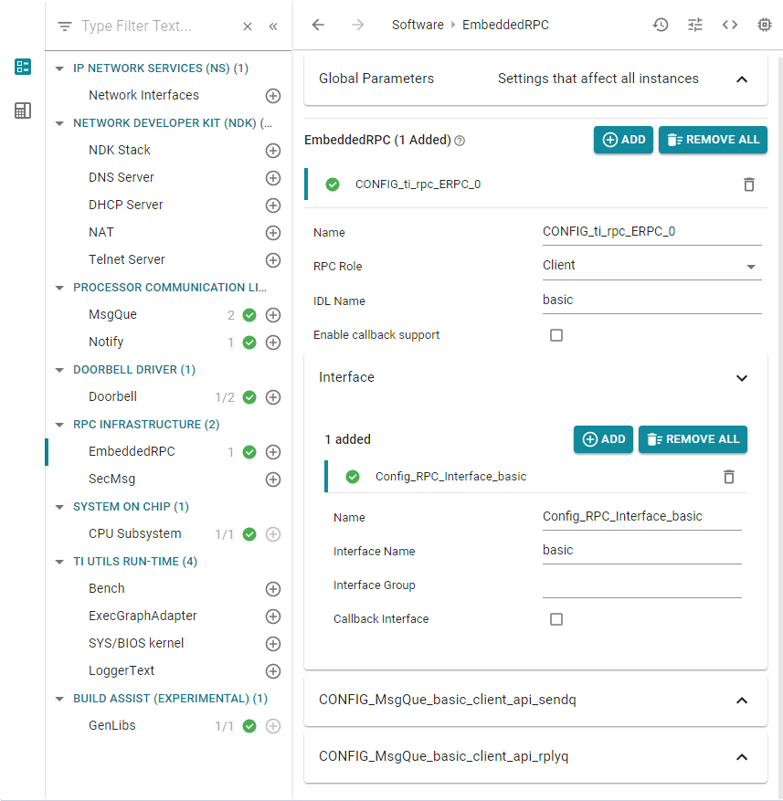

## Shared Memory RPC example

This RPC example uses shared memory as the transport for passing data between two processors. There are two ways to do this: 1. deep-copy, and 2. shallow-copy. In both cases, the shared memory provides a zero-copy transport. In other words, once the data has been marshalled into the message, only the message address is passed to the remote side. The message itself is not copied.

In the case of deep-copy marshalling, all arguments are copied into the message, including data pointed to by pointers. The benefit to this approach is that only the message pool memory is made accessible to the remote side. When using shallow-copy marshalling, only the function arguments are marshalled into the message. For a pointer argument, only the pointer value is marshalled, not the data it is pointing to. This approach requires that all local memory is accessible to the remote side, which is a less robust design.

The example consists of several parts as described below:

```
<SDK install>/examples/rtos/MTL1/rpc/tirtos/ticlang/smem/

rpc_smem_comm               - library implementation, includes IDL file
rpc_smem_comm_core0_client  - client library for IDL generated code
rpc_smem_comm_core1_server  - server library for IDL generated code
rpc_smem_core0              - client application for core-0
rpc_smem_core0_tirtos       - SYS/BIOS kernel for core-0 application
rpc_smem_core1              - server program for core-1
rpc_smem_core1_tirtos       - SYS/BIOS kernel for core-1 program
```

### Import the smem example into CCS

This example contains 7 CCS projects. Import these projects into your CCS workspace. They are located in the following folder in the SDK install:

```
<SDK>/examples/rtos/MTL1/rpc/tirtos/ticlang/smem/
```

> **Important**: After importing the example projects into your CCS workspace, you must fix up the **`rpc_smem_comm`** example before building. The project contains a README file with instructions on how to fix it.

### Build the smem example

The example produces two executables, one for each processor. You must build the following two projects, build dependencies will ensure the remaining projects are built in the correct order:

```
rpc_smem_core0
rpc_smem_core1
```

The build phase will product the following two executables, one for each processor:

```
APPS_CORE_0: rpc_smem_core0/Binaries/rpc_smem_core0.out
APPS_CORE_1: rpc_smem_core1/Binaries/rpc_smem_core1.out
```

These executables load to FLASH memory. Use the appropriate steps for your workspace to load these executables.

### Running the smem example

This example is a mixed-mode application. This means that a secure executable must loaded into the secure partition, in addition to the example program, which is loaded into the non-secure partition. Use the pre-built secure executables that ship in the SDK.

```
<SDK>/tfm_s/build/mtl1_core0_gnu/Release/outputs/MTL1/tfm_s.axf
<SDK>/tfm_s/build/mtl1_core1_gnu/Release/outputs/MTL1/tfm_s.axf
```

Furthermore, you must enable the Context Accelerator to run this example.

Use ROV to view the output of the program. Open a CCS ROV view for each processor. Open the SysMin/Buffer view. Turn on continuous refresh to see the program output while it is running.

This examples has memory controls for interacting with the execution flow. Use the CCS Expressions view to access these controls.

Enter the following names in the expression view for APPS_CORE_0:

```
App_doSend
App_doSendFrame
```

Each of these controls initiates a specific program flow. Use them one at a time. The program wakes up once a second and checks these controls. If they are non-zero, it will trigger the corresponding action.

- App_doSend - Send the current count value to the remote side

  The value of the counter is sent to the remote side. On each send, the value of App_doSend is decremented. This allows you invoke send one or more times in a row.
- App_doSendFrame - Send a data frame using shallow-copy

  This is a non-blocking call. It sends the address of the frame and a callback function to the remote side. The remote side replies immediately with a status value. After serveral seconds, the remote side invokes the callback to signal the work as been completed.

## VCR RPC example

The SDK provides an example called VCR to illustrate the RPC technology between two processors: Core-0 and Core-1. The example models a remote control access to a VCR console to help illustrate the RPC concepts, hence the name. The example consists of several parts as described below:

```
<SDK install>/examples/rtos/MTL1/rpc/tirtos/ticlang/

vcr_core0         - client application for core-0
vcr_core0_tirtos  - SYS/BIOS kernel for core-0 application
vcr_core1         - server program for core-1
vcr_core1_tirtos  - SYS/BIOS kernel for core-1 program
vcr_impl          - VCR feature library implementation, includes IDL file
vcr_skel          - RPC server library for the VCR feature library
vcr_stub          - RPC client library for the VCR feature library
```

### SimpleLink SDK Configuration

The VCR example is built using makefiles. The makefiles use `imports.mak` to located the various tools needed to build the example.

After installing the SDK, update `imports.mak` to reflect your physical development environment. The following is an example installation:

```
<SDK install>/imports.mak

SYSCONFIG_TOOLS     = $(CCS)/ccs/utils/sysconfig/sysconfig_cli.bat
TICLANG_ARMCOMPILER = $(CCS)/ccs/tools/compiler/ti-cgt-armllvm_0.1.0-alpha.5
XDC_INSTALL_DIR     = C:/Products/xdctools_3_51_03_28_core
```

### Build the example

Open a Window command prompt to build the example. Navigate to the example and build the parts in the following order:

```
cd <SDK install>/examples/rtos/MTL1/rpc/tirtos/ticlang/

make -C vcr_impl
make -C vcr_stub
make -C vcr_skel
make -C vcr_core0_tirtos
make -C vcr_core0
make -C vcr_core1_tirtos
make -C vcr_core1
```

The build commands above will produce two executables, one for each processor.

```
APPS_CORE_0: vcr_core0/vcr-core0.out
APPS_CORE_1: vcr_core1/vcr-core1.out
```

CCS may be used to run and debug this example, but the example is not yet available as a CCS Project.

### Program Interaction

This example is a mixed-mode application. This means that a secure executable must loaded into the secure partition, in addition to the example program, which is loaded into the non-secure partition. Use the pre-built secure executables that ship in the SDK.

```
<SDK>/tfm_s/build/mtl1_core0_gnu/Release/outputs/MTL1/tfm_s.axf
<SDK>/tfm_s/build/mtl1_core1_gnu/Release/outputs/MTL1/tfm_s.axf
```

Furthermore, you must enable the Context Accelerator to run this example.

Use CCS to load the executables onto their respective cores.

The VCR example will print messages to indicate program execution. These messages are routed to the SyMin Buffer, not to the CCS console view. Use ROV to see the messages.

Open an ROV view for each processor:

```
APPS_CORE_0 > Select
Tools > Runtime Object View

APPS_CORE_1 > Select
Tools > Runtime Object View
```

There are a few memory controls which you can use to affect the program flow. Use the CCS Expressions view to access these controls. Open an Expression view for each processor; be sure to pin the view to its respective core. To ensure the view contents are current, turn on Continuous Refresh using the toolbar icon.

Enter the following names in the expression view for APPS_CORE_0:

```
App_doVolStep
App_doRewind
App_doEjectCb
```

Enter the following name in the expression view for APPS_CORE_1:

```
VCR_doEject
```

Each of these controls initiates a specific program flow. Use them one at a time. The program wakes up once a second and checks these controls. If they are non-zero, it will trigger the corresponding action.

- App_doVolStep - Modify the volume by the given step amount

  The VCR server maintains the volume level. Use this control to increase or decrease the volume by the given step. Enter a value (e.g. 15), on the next wake cycle, the application will issue a blocking RPC call to change the volume. When the RPC call completes, the flag is set back to zero.
- App_doRewind - Initiate a tape rewind operation (asynchronous completion)

  This flag simulates an asynchronous completion event. Enter 1 in this control to trigger an RPC call to begin the tape rewind operation. The call returns. When the tape rewind completes (takes a few seconds), the server will send an asynchronous completion event. The application receives the completion event and prints an acknowledgement.
- App_doEjectCb - Register eject callback (App_ejectCbA or App_ejectCbB)

  This control will perform a run-time callback registration. There are two callback functions which may be registered. Enter the character ‘A’ (with single quotes) or ‘B’ to register the respective callback. On APPS_CORE_1, use the VCR_doEject control to trigger the callback. Enter ‘x’ to unregister the current callback.
- VCR_doEject - Initiate a tape eject operation (asynchronous event)

  This control issues an asynchronous event. If a callback function has been registered, it will be invoked.